# Preparation

# Problem 1

There are 8 red and 6 blue balls in a box. 2 balls are taken randomly (without return). Find statistical and theoretical probabilities that the two balls have different colors.

```python
events = ['R', 'R', 'R', 'R', 'R', 'R', 'R', 'R', 'B', 'B', 'B', 'B', 'B', 'B']
```

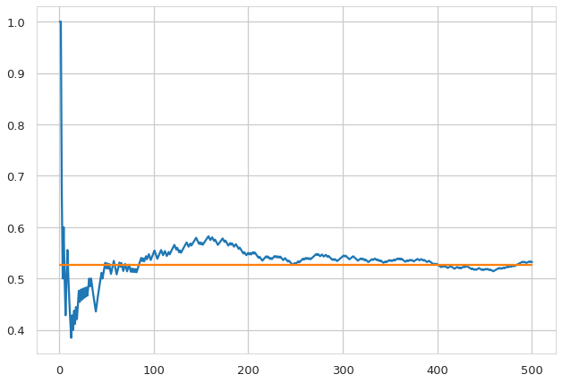

```python
P_A = []
N_A = 0

N = 500

for i in range(0, N):
    index = np.random.choice(events, size=2, replace=False)
    if {index[0], index[1]} == {'R', 'B'}:
        N_A = N_A+ 1
    P_A.append(N_A/float(i+1))

plt.plot(np.arange(1, N+1), P_A)

plt.plot(np.arange(1, N+1), [(8*6*2)/(14*13)]*N, label = 'Theoretical probability')
```

### Exrecise: Find statistical probability that, out of $n$ coin flips, you got between $k_1$ and $k_2$ heads.

```python
from math import factorial
```

```python
events = ['T', 'H']

sum(np.random.choice(events, size=100) == 'H')
```

```
53
```

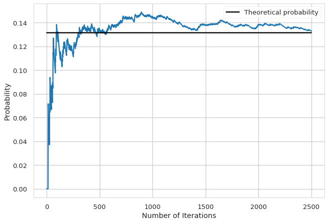

```python
P_A = []
N_A = 0

N = 2500
n = 20
k1 = 2
k2 = 8

for i in range(0, N):
    index = np.random.choice(events, size=n, replace=True)
    total = sum(index == 'H')
    if (total < k2) and (total > k1):
        N_A = N_A+ 1
    P_A.append(N_A/float(i+1))

plt.plot(np.arange(1, N+1), P_A)
plt.xlabel('Number of Iterations')
plt.ylabel('Probability')

P_theory = 0

for i in range(k1+1, k2):
    P_theory += (0.5 ** n) * (factorial(n) / (factorial(i)*factorial(n-i)))

plt.plot(range(1, N+1), [P_theory]*N, 'k', label = 'Theoretical probability') #[8*7 / 14*13] || (6*5)/14*13
plt.legend()
plt.show()
```

# Problem 3

Read the dataset "student-por.csv" in Pandas DataFrame format. Based only on the columns "G3" and "school" statistically estimate:

a) Probability that a randomly chosen student is from school "GP" and probability that the student is from school "MS".

b) Probability that a randomly chosen student has high score ("G3">=15), probability of mid score (5<"G3"<15) and probability of low score ("G3"<5).

c) Conditional probabilities that a random student has high score, given that she/he is from a particular school: 𝑃(high score|school=′𝐺𝑃′) and 𝑃(high score|school=′𝑀𝑆′).

d) Using Bayes equation calculate the probabilities: P(school=′𝐺𝑃′|high schore) and P(school=′MS′|high schore).

```python
import pandas as pd
import matplotlib.pyplot as plt

# read data:
data_por = pd.read_csv("data/student-por.csv")
data_por.head()  # pick into DataFrame
```

|  | school | sex | age | address | famsize | Pstatus | Medu | Fedu | Mjob | Fjob | ... | famrel | freetime | goout | Dalc | Walc | health | absences | G1 | G2 | G3 |
| --- | --- | --- | --- | --- | --- | --- | --- | --- | --- | --- | --- | --- | --- | --- | --- | --- | --- | --- | --- | --- | --- |
| 0 | GP | F | 18 | U | GT3 | A | 4 | 4 | at_home | teacher | ... | 4 | 3 | 4 | 1 | 1 | 3 | 4 | 0 | 11 | 11 |
| 1 | GP | F | 17 | U | GT3 | T | 1 | 1 | at_home | other | ... | 5 | 3 | 3 | 1 | 1 | 3 | 2 | 9 | 11 | 11 |
| 2 | GP | F | 15 | U | LE3 | T | 1 | 1 | at_home | other | ... | 4 | 3 | 2 | 2 | 3 | 3 | 6 | 12 | 13 | 12 |
| 3 | GP | F | 15 | U | GT3 | T | 4 | 2 | health | services | ... | 3 | 2 | 2 | 1 | 1 | 5 | 0 | 14 | 14 | 14 |
| 4 | GP | F | 16 | U | GT3 | T | 3 | 3 | other | other | ... | 4 | 3 | 2 | 1 | 2 | 5 | 0 | 11 | 13 | 13 |

5 rows × 33 columns

```python
attributes = ["G3","school"]
data_por = data_por[attributes]
data_por.head()
```

|  | G3 | school |
| --- | --- | --- |
| 0 | 11 | GP |
| 1 | 11 | GP |
| 2 | 12 | GP |
| 3 | 14 | GP |
| 4 | 13 | GP |

```python
temp=data_por.school.value_counts()
temp
```

```
GP    423
MS    226
Name: school, dtype: int64
```

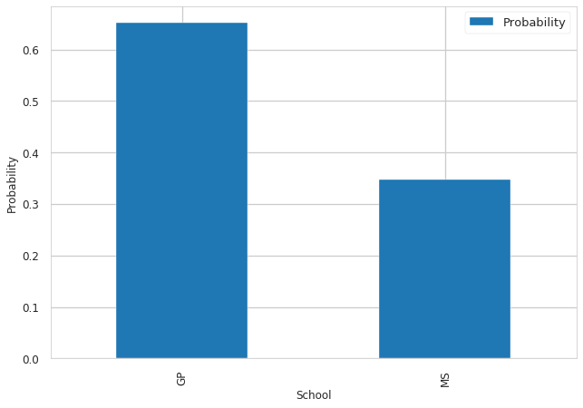

```
    Probability
GP     0.651772
MS     0.348228
```

```python
P_school = pd.DataFrame((temp/temp.sum()).sort_index())  # sort_index() - sorts according to the row names
P_school.index = ["GP","MS"]
P_school.columns = ["Probability"]  # This DataFrame has only one column

# Now we plot these probabilities (using bar plot)
P_school.plot.bar(fontsize=12)
plt.ylabel("Probability",fontsize=12)
plt.xlabel("School",fontsize=12)
plt.show()
print(P_school)
```

#### Excercies b

```python
data_temp = (data_por["G3"]>=15).value_counts()
data_temp

data_temp1 = ((data_por["G3"]>5) & (data_por["G3"]<15)).value_counts()
data_temp1

data_temp2 = (data_por["G3"]<=5).value_counts()
data_temp2
```

```
False    632
True      17
Name: G3, dtype: int64
```

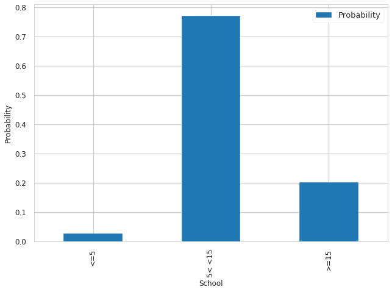

```
        Probability
<=5        0.026194
5< <15     0.771957
>=15       0.201849
```

```python
P_G3=pd.DataFrame([data_temp2[True], data_temp1[True],data_temp[True]])/len(data_por)
P_G3.index = ["<=5","5< <15",">=15"]
P_G3.columns = ["Probability"]  # This DataFrame has only one column

# Now we plot these probabilities (using bar plot)
P_G3.plot.bar(fontsize=12)
plt.ylabel("Probability",fontsize=12)
plt.xlabel("School",fontsize=12)
plt.show()
print(P_G3)
```

#### Excersice c

```python
data_temp3 = data_por[data_por["G3"]>=15]['school'].value_counts()
data_temp3
```

```
GP    100
MS     31
Name: school, dtype: int64
```

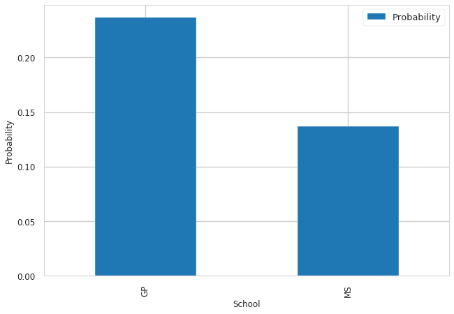

```
    Probability
GP     0.236407
MS     0.137168
```

```python
P_cond1=pd.DataFrame(data_temp3/temp)
P_cond1.columns = ["Probability"]  # This DataFrame has only one column

# Now we plot these probabilities (using bar plot)
P_cond1.plot.bar(fontsize=12)
plt.ylabel("Probability",fontsize=12)
plt.xlabel("School",fontsize=12)
plt.show()
print(P_cond1)
```

#### Excercise D

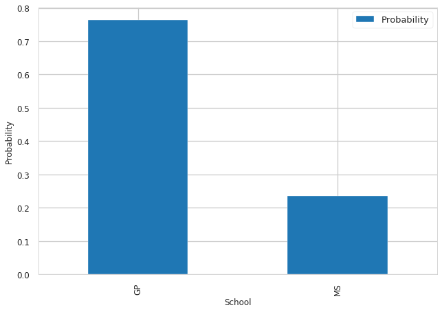

```
    Probability
GP     0.763359
MS     0.236641
```

```python
P_cond2=pd.DataFrame(P_cond1*P_school/P_G3.loc['>=15'])
P_cond2.columns = ["Probability"]  # This DataFrame has only one column

# Now we plot these probabilities (using bar plot)
P_cond2.plot.bar(fontsize=12)
plt.ylabel("Probability",fontsize=12)
plt.xlabel("School",fontsize=12)
plt.show()
print(P_cond2)
```